# TidyVerseAssignment

Joshua Registe

12/1/2019

## 0.1 R Markdown

# 1 Part I

```r
library(dplyr)
library(tidyverse)
library(fivethirtyeight)
```

the package “dplyr” has many functions used for data manipulation and provides a set of verbs that allow you to perform helpful transformations. This includes: “Mutate”, “select” “filter”, “summarise”, “arrange”,“group_by”, “order_by” and many more. This Vignette will demonstrate the intent behind these functions and how to apply them.

The dataset we will be working with is from the “FiveThirtyEight” package called "airlinesafety. this data set is shown below.

```r
airline_safety
```

```
## # A tibble: 56 x 9
##    airline incl_reg_subsid~ avail_seat_km_p~ incidents_85_99
##    <chr>   <lgl>                       <dbl>           <int>
##  1 Aer Li~ FALSE                   320906734               2
##  2 Aerofl~ TRUE                   1197672318              76
##  3 Aeroli~ FALSE                   385803648               6
##  4 Aerome~ TRUE                    596871813               3
##  5 Air Ca~ FALSE                  1865253802               2
##  6 Air Fr~ FALSE                  3004002661              14
##  7 Air In~ TRUE                    869253552               2
##  8 Air Ne~ TRUE                    710174817               3
##  9 Alaska~ TRUE                    965346773               5
## 10 Alital~ FALSE                   698012498               7
## # ... with 46 more rows, and 5 more variables:
## #   fatal_accidents_85_99 <int>, fatalities_85_99 <int>,
## #   incidents_00_14 <int>, fatal_accidents_00_14 <int>,
## #   fatalities_00_14 <int>
```

```r
str(airline_safety)
```

```
## Classes 'tbl_df', 'tbl' and 'data.frame':    56 obs. of  9 variables:
##  $ airline               : chr  "Aer Lingus" "Aeroflot" "Aerolineas Argentinas" "Aeromexico" ...
##  $ incl_reg_subsidiaries : logi  FALSE TRUE FALSE TRUE FALSE FALSE ...
##  $ avail_seat_km_per_week: num  3.21e+08 1.20e+09 3.86e+08 5.97e+08 1.87e+09 ...
##  $ incidents_85_99       : int  2 76 6 3 2 14 2 3 5 7 ...
##  $ fatal_accidents_85_99 : int  0 14 0 1 0 4 1 0 0 2 ...
##  $ fatalities_85_99      : int  0 128 0 64 0 79 329 0 0 50 ...
##  $ incidents_00_14       : int  0 6 1 5 2 6 4 5 5 4 ...
##  $ fatal_accidents_00_14 : int  0 1 0 0 0 2 1 1 1 0 ...
##  $ fatalities_00_14      : int  0 88 0 0 0 337 158 7 88 0 ...
```

## 1.1 Select

select - This function allows you to select specific a variables from a dataset, for example, if we wanted to select just the “airline” fieldn and “incl_reg_subsidiaries” field we would perform the following operation:

```r
airline_safety%>% select(airline,incl_reg_subsidiaries)
```

```
## # A tibble: 56 x 2
##    airline               incl_reg_subsidiaries
##    <chr>                 <lgl>
##  1 Aer Lingus            FALSE
##  2 Aeroflot              TRUE
##  3 Aerolineas Argentinas FALSE
##  4 Aeromexico            TRUE
##  5 Air Canada            FALSE
##  6 Air France            FALSE
##  7 Air India             TRUE
##  8 Air New Zealand       TRUE
##  9 Alaska Airlines       TRUE
## 10 Alitalia              FALSE
## # ... with 46 more rows
```

## 1.2 Filter

Filter allows us to drill deeper into our dataset and retain subsets of that data, for example, if we wish to extract only True values of "incl_reg_subsidiaries we would perform the following operation:

```r
airline_safety%>% filter(incl_reg_subsidiaries==TRUE)
```

```
## # A tibble: 16 x 9
##    airline incl_reg_subsid~ avail_seat_km_p~ incidents_85_99
##    <chr>   <lgl>                       <dbl>           <int>
##  1 Aerofl~ TRUE                   1197672318              76
##  2 Aerome~ TRUE                    596871813               3
##  3 Air In~ TRUE                    869253552               2
##  4 Air Ne~ TRUE                    710174817               3
##  5 Alaska~ TRUE                    965346773               5
##  6 Americ~ TRUE                   5228357340              21
##  7 Britis~ TRUE                   3179760952               4
##  8 Cathay~ TRUE                   2582459303               0
##  9 Delta ~ TRUE                   6525658894              24
## 10 KLM     TRUE                   1874561773               7
## 11 Luftha~ TRUE                   3426529504               6
## 12 Qantas  TRUE                   1917428984               1
## 13 SAS     TRUE                    682971852               5
## 14 SWISS   TRUE                    792601299               2
## 15 United~ TRUE                   7139291291              19
## 16 US Air~ TRUE                   2455687887              16
## # ... with 5 more variables: fatal_accidents_85_99 <int>,
## #   fatalities_85_99 <int>, incidents_00_14 <int>,
## #   fatal_accidents_00_14 <int>, fatalities_00_14 <int>
```

## 1.3 Summarise

summarise is a tool that allows us to compute statistics or custom functions on variables within our dataset. an example of this is shown below by computing both the mean, and the number of observations on safety incidents that occurred between the years 2000 and 2014.

```r
airline_safety %>% summarise(mean = mean(incidents_00_14), n= n())
```

```
## # A tibble: 1 x 2
##    mean     n
##   <dbl> <int>
## 1  4.12    56
```

## 1.4 Mutate

Mutate is a tool that allows us to transform our dataset using functions and transformations that we desire. For example, on this airline dataset we can add incidents that occured between 2000 and 2014 (variable "incidents_00_14) with incidents between 1985 and 1999

```r
airline_safety %>%
  mutate(All_Incidents = incidents_85_99+incidents_00_14) %>%
  select(All_Incidents)
```

```
## # A tibble: 56 x 1
##    All_Incidents
##            <int>
##  1             2
##  2            82
##  3             7
##  4             8
##  5             4
##  6            20
##  7             6
##  8             8
##  9            10
## 10            11
## # ... with 46 more rows
```

## 1.5 Group By

```r
airline_safety %>%
  mutate(All_Incidents = incidents_85_99+incidents_00_14) %>%
  group_by(incl_reg_subsidiaries,sum= sum(All_Incidents))
```

```
## # A tibble: 56 x 11
## # Groups:   incl_reg_subsidiaries, sum [2]
##    airline incl_reg_subsid~ avail_seat_km_p~ incidents_85_99
##    <chr>   <lgl>                       <dbl>           <int>
##  1 Aer Li~ FALSE                   320906734               2
##  2 Aerofl~ TRUE                   1197672318              76
##  3 Aeroli~ FALSE                   385803648               6
##  4 Aerome~ TRUE                    596871813               3
##  5 Air Ca~ FALSE                  1865253802               2
##  6 Air Fr~ FALSE                  3004002661              14
##  7 Air In~ TRUE                    869253552               2
##  8 Air Ne~ TRUE                    710174817               3
##  9 Alaska~ TRUE                    965346773               5
## 10 Alital~ FALSE                   698012498               7
## # ... with 46 more rows, and 7 more variables:
## #   fatal_accidents_85_99 <int>, fatalities_85_99 <int>,
## #   incidents_00_14 <int>, fatal_accidents_00_14 <int>,
## #   fatalities_00_14 <int>, All_Incidents <int>, sum <int>
```

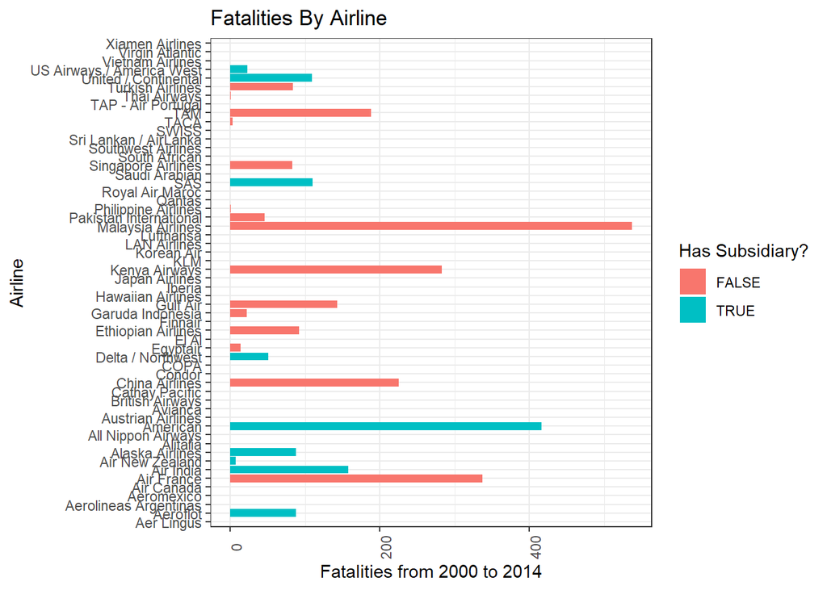

```r
airline_safety %>% ggplot(aes(x=airline,fatal_accidents_00_14, y = fatalities_00_14))+
  geom_col(aes(fill = incl_reg_subsidiaries))+
  theme_bw()+
  theme(axis.text.x = element_text(angle = 90))+coord_flip()+
  labs(title = "Fatalities By Airline",
       x = "Airline",
       y = "Fatalities from 2000 to 2014",
       fill = "Has Subsidiary?")
```

# 2 Part 2

## 2.2 Rpubs link: http://rpubs.com/ssufian/548044

## 2.3 Github: https://github.com/ssufian/FALL2019TIDYVERSE/blob/master/Data-607-Tidyverse-Project-orig.Rmd

## 2.4 R Problem Statement:

In this assignment, we will practice collaborating around a code project with Github as a class.

Using several TidyVerse packages, and the “How Popular is Trump?” dataset from

fivethirtyeight.com, I’m going to show a programming sample “vignette” that demonstrates how to use the

capabilities of ggplot2, dplyr, readr packages with this particular dataset.

```r
# Load
library("tidyverse")
library(ggplot2)
library(dplyr)
```

## 2.5 Using readr to read data from a csv file (Github site)

```r
polls <- read_csv("https://raw.githubusercontent.com/ssufian/Data_607/master/approval_topline.csv")
polls1 <- read_csv('https://raw.githubusercontent.com/ssufian/Data_607/master/polling_data.csv')
```

## 2.6 Using ggplot2 to visualizae data; with pipe operation %>% from dplyr

```r
polls1 <- as_tibble(polls1)
```

## 2.7 Bar Charts of Trump’s approval/disapproval ratings by pollster types shown below:

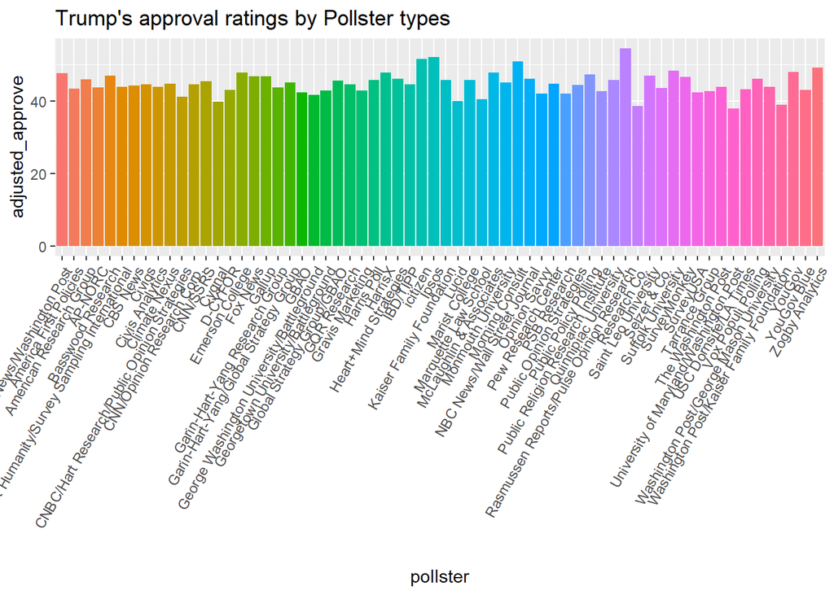

```r
polls1 %>% ggplot(aes(x=pollster, y=adjusted_approve, fill=pollster))+
  geom_bar(stat = "identity", position = "dodge") +
  guides(fill = FALSE) +
  ggtitle("Trump's approval ratings by Pollster types")+
  theme(axis.text.x = element_text(angle = 60, hjust = 1))
```

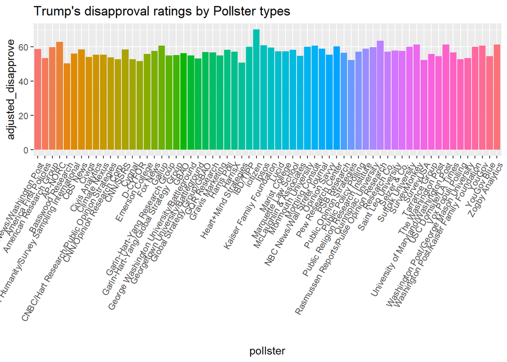

```r
polls1 %>% ggplot(aes(x=pollster, y=adjusted_disapprove, fill=pollster))+
  geom_bar(stat = "identity", position = "dodge") +
  guides(fill = FALSE) +
  ggtitle("Trump's disapproval ratings by Pollster types")+
  theme(axis.text.x = element_text(angle = 60, hjust = 1))
```

## 2.8 Trumps Approval/Dis-approval ratings by voter types:

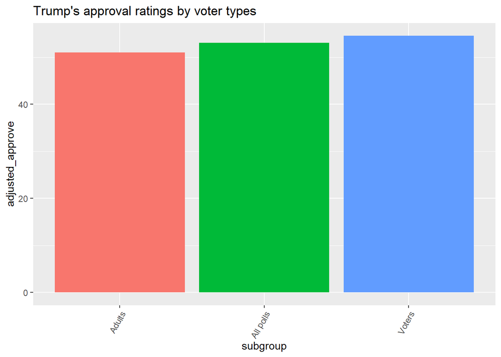

```r
polls1 %>% ggplot(aes(x=subgroup, y=adjusted_approve, fill=subgroup))+
  geom_bar(stat = "identity", position = "dodge") +
  guides(fill = FALSE) +
  ggtitle("Trump's approval ratings by voter types")+
  theme(axis.text.x = element_text(angle = 60, hjust = 1))
```

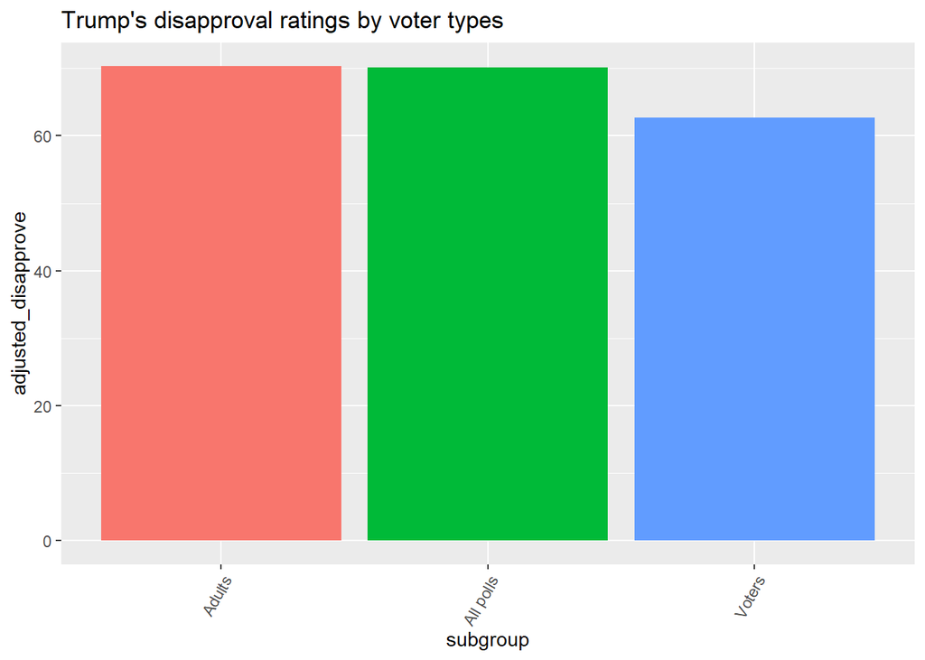

```r
polls1 %>% ggplot(aes(x=subgroup, y=adjusted_disapprove, fill=subgroup))+
  geom_bar(stat = "identity", position = "dodge") +
  guides(fill = FALSE) +
  ggtitle("Trump's disapproval ratings by voter types")+
  theme(axis.text.x = element_text(angle = 60, hjust = 1))
```

##Joshua’s Extension

Adding an extension to Sufian’s code using a dplyr function to average out approval ratings by group as a new column.

```r
polls %>% group_by(subgroup)%>%
  mutate(Average_of_Approval_Estimate = mean(approve_estimate))
```

```
## # A tibble: 3,051 x 11
## # Groups:   subgroup [3]
##    president subgroup modeldate approve_estimate approve_hi approve_lo
##    <chr>     <chr>    <chr>                <dbl>      <dbl>      <dbl>
##  1 Donald T~ Voters   11/5/2019             42.4       46.7       38.1
##  2 Donald T~ Adults   11/5/2019             41.1       44.9       37.2
##  3 Donald T~ All pol~ 11/5/2019             41.4       45.6       37.2
##  4 Donald T~ Adults   11/4/2019             40.6       44.4       36.8
##  5 Donald T~ Voters   11/4/2019             41.5       45.7       37.4
##  6 Donald T~ All pol~ 11/4/2019             41.1       45.3       36.8
##  7 Donald T~ Voters   11/3/2019             41.6       45.8       37.4
##  8 Donald T~ Adults   11/3/2019             40.6       44.4       36.8
##  9 Donald T~ All pol~ 11/3/2019             41.2       45.4       36.9
## 10 Donald T~ Adults   11/2/2019             40.0       43.3       36.6
## # ... with 3,041 more rows, and 5 more variables:
## #   disapprove_estimate <dbl>, disapprove_hi <dbl>, disapprove_lo <dbl>,
## #   timestamp <chr>, Average_of_Approval_Estimate <dbl>
```